# GSB 544 Lab 4

Author

Eddie Cagney

## Packages and Loading Data

```python
import requests
from bs4 import BeautifulSoup
import pandas as pd
import re
```

```python
URL = "https://tastesbetterfromscratch.com/meal-plan-210"
HEADERS ={ "User-Agent": "Mozilla/5.0 (Windows NT 10.0; Win64; x64)" }


# get the html content
response = requests.get(URL, headers = HEADERS)
soup = BeautifulSoup(response.content, "html.parser")
```

Here I’m printing the first 500 indexes in file to show that it works.

```python
file = soup.find("article") or soup
print(str(file)[:500])
```

```
<article class="type-post grow-content-body"><div class="entry-content"><div class="dpsp-content-wrapper dpsp-shape-rectangular dpsp-size-medium dpsp-has-spacing dpsp-no-labels-mobile dpsp-hide-on-mobile dpsp-button-style-6" id="dpsp-content-top" style="min-height:40px;position:relative">
<ul class="dpsp-networks-btns-wrapper dpsp-networks-btns-share dpsp-networks-btns-content dpsp-column-auto dpsp-has-button-icon-animation" style="padding:0;margin:0;list-style-type:none">
<li class="dpsp-networ
```

# 1

```python
rows = []

for p in file.find_all("p"):
    strong = p.get_text(" ", strip = True)
    day = re.findall(r"^\s*(Monday|Tuesday|Wednesday|Thursday|Friday)", strong)
    if not day:
        continue

    a = p.find("a", href=True)
    if not (strong and a):
        continue

    day_of_week = day[0]
    name = a.get_text(strip = True)
    link = a['href']

    price_recipe = re.findall(r"\$\d+(?:\.\d{2})?", strong)
    price = price_recipe[0]


    rows.append({
        "Day of the Week": day_of_week,
        "Name of Recipe": name,
        "Link to Recipe": link,
        "Price of Recipe": price
    })

df = pd.DataFrame(rows)
print(df)
```

```
  Day of the Week           Name of Recipe  \
0          Monday  Biscuit Chicken Pot Pie
1         Tuesday                  Calzone
2       Wednesday            Quinoa Burger
3        Thursday           Short Rib Ragu
4          Friday        Cabbage Roll Soup

                                      Link to Recipe Price of Recipe
0  https://tastesbetterfromscratch.com/biscuit-ch...             $11
1      https://tastesbetterfromscratch.com/calzones/              $8
2  https://tastesbetterfromscratch.com/quinoa-veg...             $15
3  https://tastesbetterfromscratch.com/short-rib-...             $26
4  https://tastesbetterfromscratch.com/cabbage-ro...             $20
```

# 2

```python
url = "https://tasty.p.rapidapi.com/recipes/list"

querystring = {"from":"0","size":"20","q":"Biscuit Chicken Pot Pie"}

headers = {
    "x-rapidapi-key": "10bff72081msh0d8b0bbdb700e4ap1d07bfjsn04ddcf3e4d60",
    "x-rapidapi-host": "tasty.p.rapidapi.com"
}

response = requests.get(url, headers=headers, params=querystring)
```

```python
monday_recipes = pd.json_normalize(response.json(), "results")
print(monday_recipes)
print(f'The number of matching recipes is: {len(monday_recipes)}')
```

```
   approved_at aspect_ratio  \
0   1550254399          1:1
1   1511237133          1:1
2   1520283577          1:1
3   1670877687          1:1
4   1605132045          1:1
5   1603892876          1:1
6   1627396212          1:1

                                          beauty_url  brand  brand_id  \
0                                               None    NaN       NaN
1                                               None    NaN       NaN
2  https://img.buzzfeed.com/video-api-prod/assets...    NaN       NaN
3                                               None    NaN       NaN
4  https://img.buzzfeed.com/video-api-prod/assets...    NaN      50.0
```

[output cut: 59 more lines]

# 3

```python
def get_weekly_plan(num):
    URL_auto = f"https://tastesbetterfromscratch.com/meal-plan-{num}"
    HEADERS_auto ={ "User-Agent": "Mozilla/5.0 (Windows NT 10.0; Win64; x64)" }
    # get the html content
    response_auto = requests.get(URL_auto, headers = HEADERS_auto)
    soup_auto = BeautifulSoup(response_auto.content, "html.parser")

    file_auto = soup_auto.find("article") or soup_auto

    rows = []
    for p in file_auto.find_all("p"):
        strong = p.get_text(" ", strip = True)
        day = re.findall(r"^\s*(Monday|Tuesday|Wednesday|Thursday|Friday)", strong)
        if not day:
            continue

        a = p.find("a", href=True)
        if not (strong and a):
            continue

        day_of_week = day[0]
        name = a.get_text(strip = True)
        link = a['href']

        price_recipe = re.findall(r"\$\d+(?:\.\d{2})?", strong)
        price = price_recipe[0]

        rows.append({
            "Day of the Week": day_of_week,
            "Name of Recipe": name,
            "Link to Recipe": link,
            "Price of Recipe": price
            })

    df = pd.DataFrame(rows)
    return(df)
```

Checking to see if `get_weekly_plan()` workds

```python
see = get_weekly_plan(210)
```

```python
for name in see['Name of Recipe']:
    recipe_name = name.strip()

recipe_name
```

```
'Cabbage Roll Soup'
```

```python
def match_recipe(name):
    url = "https://tasty.p.rapidapi.com/recipes/list"

    querystring = {"from":"0","size":"20","q":f"{name}"}

    headers = {
        "x-rapidapi-key": "10bff72081msh0d8b0bbdb700e4ap1d07bfjsn04ddcf3e4d60",
        "x-rapidapi-host": "tasty.p.rapidapi.com"
        }

    response = requests.get(url, headers=headers, params=querystring)

    x = pd.json_normalize(response.json(), "results")
    return(x)
```

Checking to See if `match_recipe()` function works

```python
check = match_recipe("Ground Beef Tacos")
```

Combining functions to create `get_meal_plan_data()` function

```python
def get_mealplan_data(num):
    df = get_weekly_plan(num)

    matches = []

    for name in df['Name of Recipe']:
        recipe_name = name.strip()
        matches.append(len(match_recipe(recipe_name)))

    df['Matched Recipes'] = matches


    return(df)
```

Based on Dr. Ross’s directions in discord I added the amount o recipes matched to another column in the dataset within the `get_mealplan_data()` function

```python
df = get_mealplan_data(202)
```

# 4

Using `beef` and `chicken` as “non- vegetarian” titles.

```python
df["Vegetarian"] = df.apply(
    lambda row: not bool(re.search(r"\b(beef|chicken)\b",
                                   str(row["Name of Recipe"]),
                                   flags=re.I)),
    axis=1
)
```

# 5

```python
def get_mealplan_data_and_nutrition(num):
    df = get_weekly_plan(num)

    matches = []
    calories = []

    for name in df['Name of Recipe']:
        recipe_name = name.strip()
        matched_recipes = match_recipe(recipe_name)
        matches.append(len(matched_recipes))

        #calories.append(matched_recipes['nutrition.fat'])

        s = pd.to_numeric(
            matched_recipes.get('nutrition.calories', pd.Series(dtype='float64')),
            errors='coerce'
        ).dropna()
        calories.append(s.mean() if not s.empty else None)

    df['Matched Recipes'] = matches
    df['Average Calories'] = calories


    #calories = []



    return(df)
```

```python
df_for_viz = get_mealplan_data_and_nutrition(202)
```

```python
df_for_viz["Vegetarian"] = df_for_viz.apply(
    lambda row: not bool(re.search(r"\b(beef|chicken)\b",
                                   str(row["Name of Recipe"]),
                                   flags=re.I)),
    axis=1
)
```

Selecting only Tuesday-Friday because we didn’t get any matches for Monday and don’t want to create a misleading plot (explained further below).

```python
df_for_viz_plot = df_for_viz.iloc[1:5]
```

```python
from plotnine import *
```

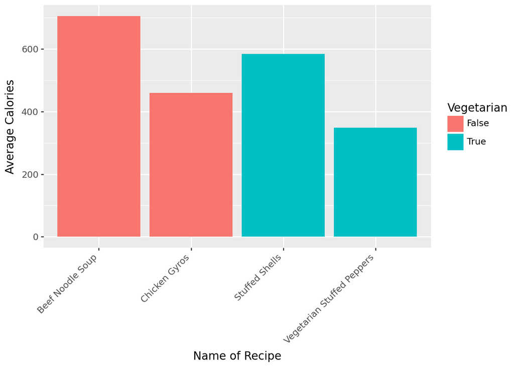

```python
(ggplot(df_for_viz_plot,
aes(
    x = 'Name of Recipe',
    y = 'Average Calories',
    fill = 'Vegetarian'
    ))
    + geom_col()
    + theme(axis_text_x = element_text(angle = 45, hjust = 1, vjust = 1))
)
```

From the data we collected, we are able to see that of the recipes that were matched with the Meal Plan #202, the recipies that are not vegetarian appear to have higher calories on average then the vegetarian options. We were not able to visualize the Chicken Divan dish because we recieved zero matches. Filtering out Monday is the best thing to do in this plot because keeping it in would result in a visualization that would look like matching recipes for Chicken Divan had an average of 0 calories when in fact there just wasn’t a match.